[figure not shown]

# Android Fundamentals

## Unit 1: Get started

### 2.1 Activities and intents

- Introduction
- What you'll learn
- What you'll do

#### Tasks

- Task 1: Create the TwoActivities project
- Task 2: Create and launch the second activity
- Task 3: Send data from the main activity to the second activity
- Task 4: Return data back to the main activity

#### Code Challenge

[Vocabulary words and concepts glossary](https://developers.google.com/android/for-all/vocab-words/)

1. Introduction

An Activity represents a single screen in your app with which your user can perform a single, focused task such as taking a photo, sending an email, or viewing a map. An activity is usually presented to the user as a full-screen window.

An app usually consists of multiple screens that are loosely bound to each other. Each screen is an activity. Typically, one activity in an app is specified as the "main" activity (MainActivity.java), which is presented to the user when the app is launched. The main activity can then start other activities to perform different actions.

Each time a new activity starts, **the previous activity is stopped**, but the system preserves the activity in a **stack** (the "back stack"). When a new activity starts, that new activity is pushed onto the back stack and takes user focus. The back stack follows basic "last in, first out" stack logic. When the user is done with the current activity and presses the Back button, that activity is popped from the stack and destroyed, and the previous activity resumes.

An activity is started or activated with an intent. An Intent is an asynchronous message that you can use in your activity to request an action from another activity, or from some other app component. You use an intent to start one activity from another activity, and to pass data between activities.

An Intent can be explicit or implicit:

- An explicit intent is one in which you know the target of that intent. That is, you already know the fully qualified class name of that specific activity.
- An implicit intent is one in which you do not have the name of the target component, but you have a general action to perform.

> You should be able to:
> - Create and run apps in Android Studio.
> - Use the layout editor to create a layout within a ConstraintLayout
> - Edit the layout XML code.
> - Add onClick functionality to a Button.
1. What you'll learn
   - How to create a new Activity in Android Studio.
   - How to define parent and child activities for Up navigation.
   - How to start an Activity with an explicit Intent.
   - How to pass data between each Activity with an explicit Intent.
1. What you'll do
   - Create a new Android app with a main Activity and a second Activity.
   - Pass some data (a string) from the main Activity to the second using an Intent, and display that data in the second Activity.
   - Send a second different bit of data back to the main Activity, also using an Intent.

## App overview

In this chapter you create and build an app called Two Activities that, unsurprisingly, contains two Activity implementations. You build the app in three stages.

In the first stage, you create an app whose main activity contains one button, Send. When the user clicks this button, your main activity uses an intent to start the second activity.

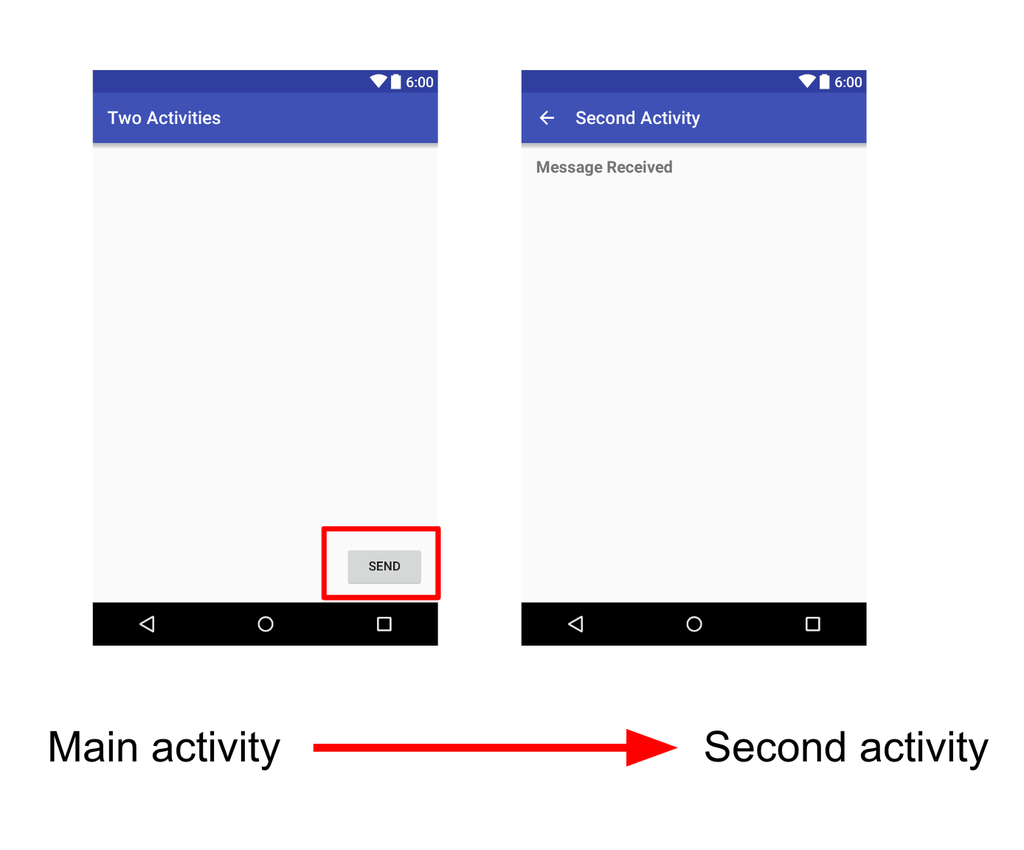

In the second stage, you add an `EditText` view to the main activity. The user enters a message and clicks `Send`. The main activity uses an intent to start the second activity and send the user's message to the second activity. The second activity displays the message it received.

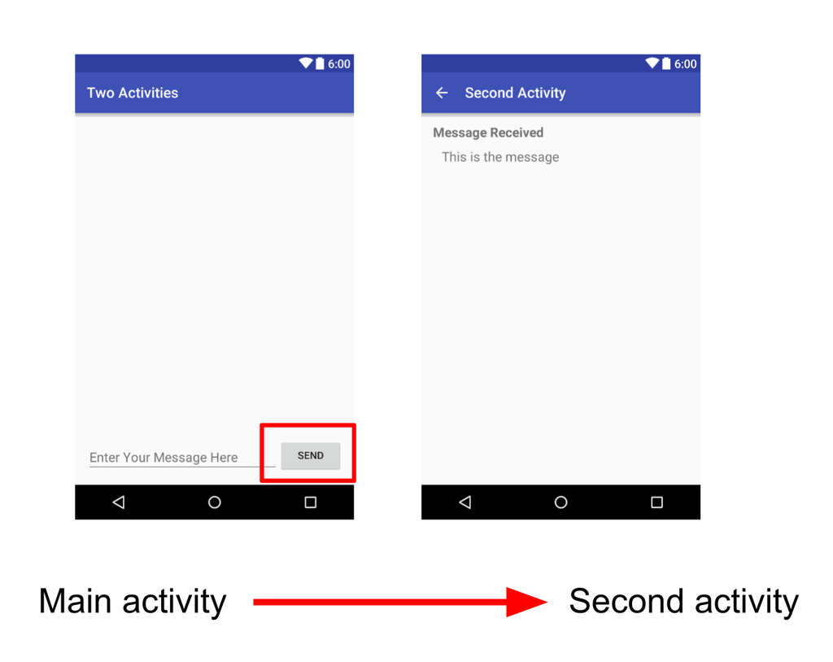

In the final stage of creating the Two Activities app, you add an `EditText` and a **Reply** button to the second activity. The user can now type a reply message and tap Reply, and the reply is displayed on the main activity. At this point, you use an intent to pass the reply back from the second activity to the main activity.

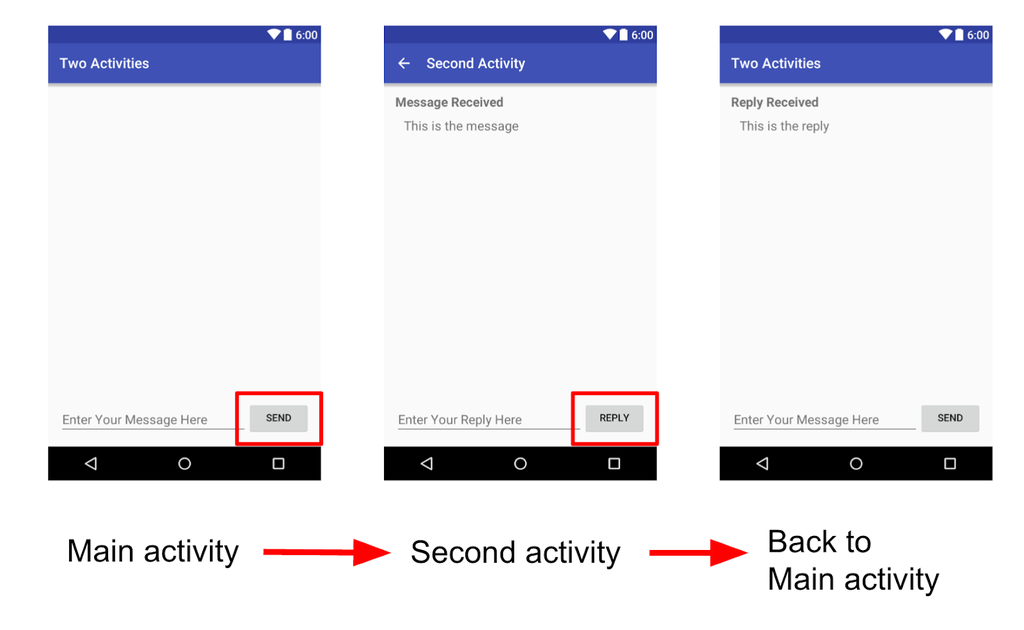

## Task 1: Create the TwoActivities project

#### 1.1 Create the TwoActivities project

#### 1.2 Define the layout for the main Activity

#### 1.3 Define the Button action

## Task 2: Create and launch the second Activity

#### 2.1 Create the second Activity

#### 2.2 Modify the AndroidManifest.xml file

#### 2.3 Define the layout for the second Activity

#### 2.4 Add an Intent to the main Activity

## Task 3: Send data from the main Activity to the second Activity

#### 3.1 Add an EditText to the MainActivity layout

#### 3.2 Add a string to the Intent extras

#### 3.3 Add a TextView to SecondActivity for the message

#### 3.4 Modify SecondActivity to get the extras and display the message

## Task 4: Return data back to the main Activity

#### 4.1 Add an EditText and a Button to the SecondActivity layout

#### 4.2 Create a response Intent in the second Activity

#### 4.3 Add TextView elements to display the reply

#### 4.4 Get the reply from the Intent extra and display it

## [Solution code](https://github.com/google-developer-training/android-fundamentals-apps-v2/tree/master/TwoActivities)

## Coding challenge

**Challenge:** Create an app with three Button elements labeled Text One, Text Two, and Text Three. When any of these Button elements are clicked, launch a second Activity. That second Activity should contain a ScrollView that displays one of three text passages (you can include your choice of passages). Use an Intent to launch the second Activity with extras to indicate which of the three passages to display.